# Reproducible Research: Peer Assessment 1

In order to answer the questions set up in this assignment, the first step is to read the data into a suitable format.

```r
knitr::opts_chunk$set(echo = TRUE)
data <- read.csv("activity.csv",stringsAsFactors = FALSE)
data[,2] <- as.Date(data[,2], "%Y-%m-%d")
```

## 1. What is mean total number of steps taken per day?

To answer it, the following steps will be taken:

- Calculate the total number of steps taken per day

```r
library(dplyr)
total_steps <- data%>%group_by(date)%>%summarise(steps=sum(steps))
```

- A histogram of the total number of steps taken each day is shown

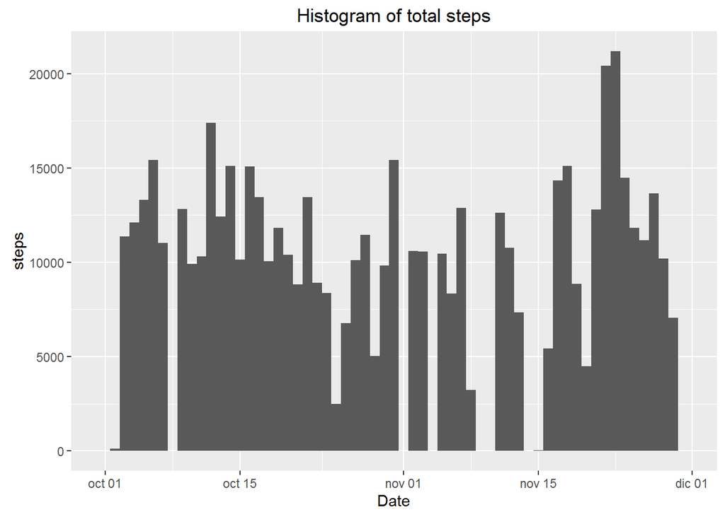

```r
library(ggplot2)
ggplot(total_steps, aes(x=date)) + geom_histogram(binwidth = 1, aes(weight=steps)) + labs(x="Date", y="steps", title="Histogram of total steps")
```

This ilustrate the result of the mean and median of the total number of steps taken per day that answer our initial question.

```r
mean(total_steps$steps, na.rm = TRUE)
```

```
## [1] 10766.19
```

```r
median(total_steps$steps, na.rm = TRUE)
```

```
## [1] 10765
```

## 2. What is the average daily activity pattern?

To ilustrate again the answer, it is made a time series plot of the 5-minute interval (x-axis) and the average number of steps taken, averaged across all days (y-axis)

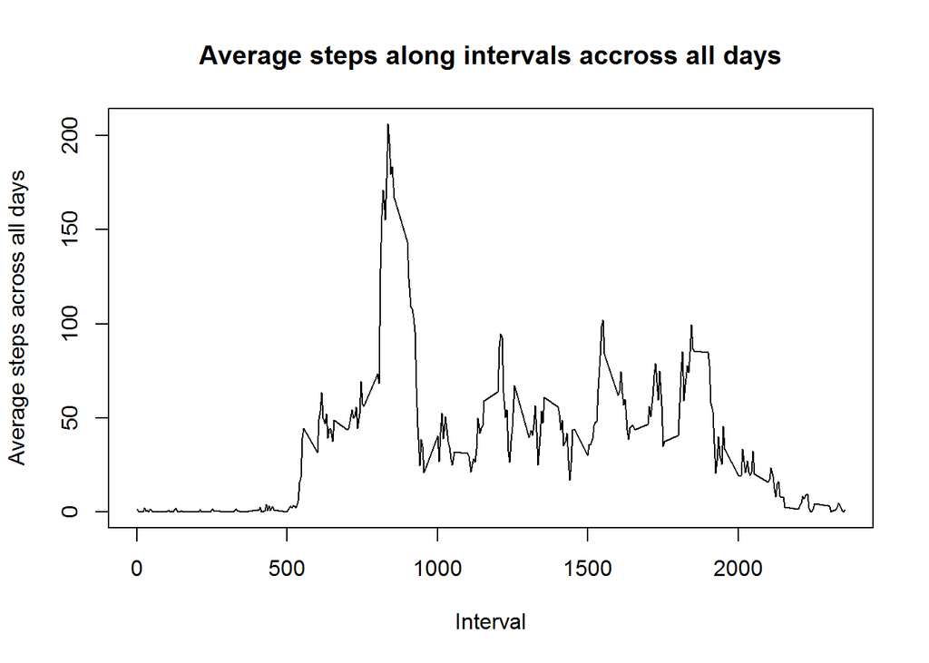

```r
avg_step_interval <- data%>%group_by(interval)%>%summarise(avg_step=mean(steps, na.rm = TRUE))
with(avg_step_interval, plot(interval, avg_step, xlab = "Interval", ylab="Average steps across all days", main = "Average steps along intervals accross all days", type = "l"))
```

The maximum number of steps, on average across all the days in the dataset:

```r
library(knitr)
kable(avg_step_interval[which.max(avg_step_interval$avg_step), ])
```

| interval | avg_step |
| --- | --- |
| 835 | 206.1698 |

## Inputing missing data

The total number of missing values in the dataset

```r
sum(is.na(data$steps))
```

```
## [1] 2304
```

The following code will filling in all of the missing values in the dataset.

```r
no_na_data <- vector("numeric", sum(is.na(data$steps)))
for(i in seq_along(data[[1]])){
  if(is.na(data[[i,1]]) == TRUE){
    intervl <- data[i,3]
      no_na_data[[i]] <- filter(avg_step_interval, interval==intervl)%>%select(avg_step)%>%unlist
  }else{
    NULL
  }
}
```

As a result, this new dataset that is equal to the original dataset but with the missing data filled in.

```r
new_data <- data[,]
new_data[, "steps_fills_na"] <- no_na_data
new_data[, "new_steps"] <- ifelse(is.na(new_data[,1]), new_data$steps_fills_na, new_data$steps)
```

Here is a histogram of the total number of steps taken each day:

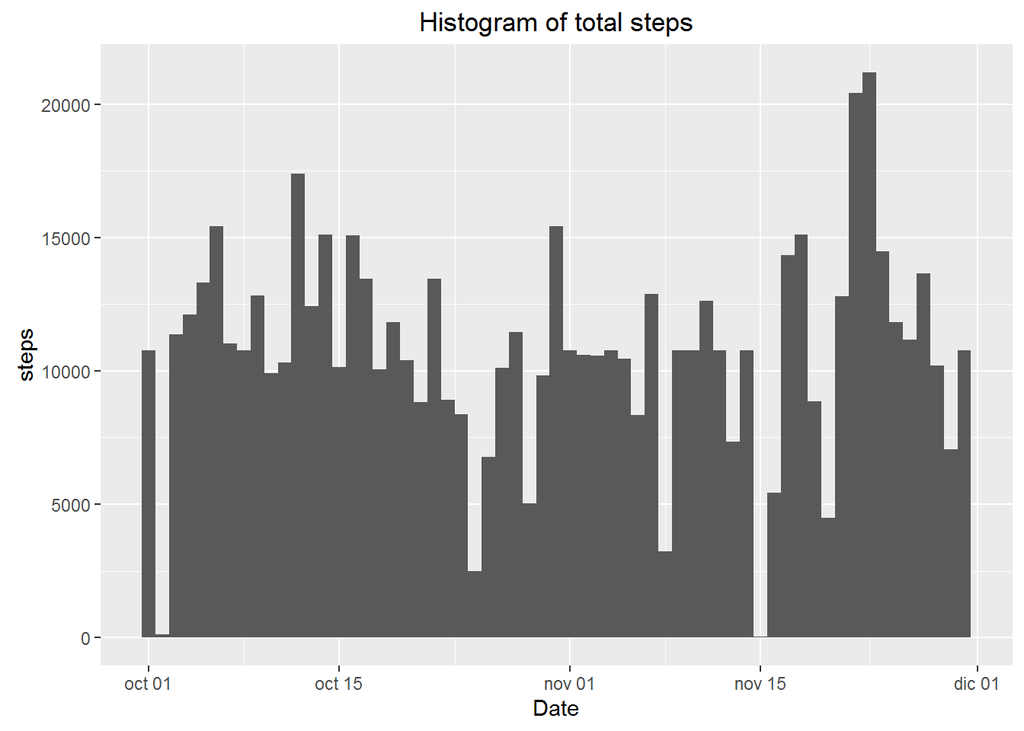

```r
ggplot(new_data, aes(x=date)) + geom_histogram(binwidth = 1, aes(weight=new_steps)) + labs(x="Date", y="steps", title="Histogram of total steps")
```

In that way, the mean and median total number of steps taken per day are:

```r
new_total_steps <- new_data%>%group_by(date)%>%summarise(total_steps=sum(new_steps))
mean(new_total_steps$total_steps)
```

```
## [1] 10766.19
```

```r
median(new_total_steps$total_steps)
```

```
## [1] 10766.19
```

# Are there differences in activity patterns between weekdays and weekends?

A new factor variable will be created in the dataset with two levels – “weekday” and “weekend” indicating whether a given date is a weekday or weekend day.

```r
weekdays <- weekdays(new_data$date)
new_data[, "week"] <- as.factor(ifelse(weekdays == "sábado" | weekdays == "domingo", "weekend", "weekday"))
```

Now, a plot of the 5-minute interval (x-axis) and the average number of steps taken, averaged across all weekday days or weekend days (y-axis) will ilustrate the difference between the average steps taken on weekends or weekdays.

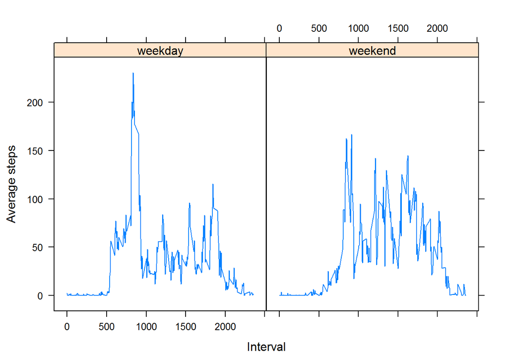

```r
library(lattice)
avg_step_weekend <- new_data%>%filter(week == "weekend")%>%select(week, interval, new_steps)%>%group_by(interval)%>%summarise(avg_step=mean(new_steps, na.rm = TRUE), week= "weekend")
avg_step_weekday <- new_data%>%filter(week == "weekday")%>%select(week, interval, new_steps)%>%group_by(interval)%>%summarise(avg_step=mean(new_steps, na.rm = TRUE), week= "weekday")
avg_step_week <- rbind(avg_step_weekday, avg_step_weekend)

xyplot(avg_step~interval | week, data = avg_step_week, xlab = "Interval", ylab = "Average steps", type = "l")
```